# determinants of liver disease

BMIN503/EPID600 Final Project

Author

Samiran Mukherjee

## 1 Overview

Using NHANES data, we aim to predict the determinants of liver steatosis and fibrosis (using the publically available fibroscan data). In addition, we will also learn to train a machine learning model to identify variables that can best predict the occurence of fibrosis. .

## 3 Methods

We will be using NHANES data to assess the determinants of advanced fibrosis from the link https://wwwn.cdc.gov/nchs/nhanes/continuousnhanes/default.aspx?Cycle=2017-2020

From the multiple data sets availabe from 2017-2020, we will be using the following files for the following: 1) demo_data; Demographic data 2) hepq_data; Hepatitis questionnaire data 3) lab_data; Lab data 4) dmq_data; dmq (diabetes questionnaire) data 5) a1c_data; a1c (diabetes lab) data 6) hepb_data; hepatitis b data 7) hepc_data; Hepatitis c data 8) fibroscan_data; Fibroscan (firbous elastography) data 9) insurance_data; insurance data 10)alcohol_data; Alcohol data

The study plan will comprise of

1) Identifying cases and controls using the fibroscan data

2) Use logistic regression models to identify variables that are associated with cases

3)create a supervised machine learning model to predict the occurence of steatosis

4) Plotting AUC curves for the same

6) create an unsupervised machine model (Kmeans clustering) and plot cases vs controls

Install packages

```r
#install.packages("modelsummary")
#install.packages("ggplot2")
#install.packages("dplyr")
#install.packages("haven")
#install.packages("tidyverse")
#install.packages("tidyr")
#install.packages("kernlab")
#install.packages("randomForest")
#install.packages("glmnet")
#install.packages("tidymodels")
#install.packages("dotwhisker")
#install.packages("vip")
#install.packages("Rtsne")
#install.packages("cowplot")
#install.packages("ggdendro")
```

Load packages

```r
library(tidyverse)
library(modelsummary)
library(dplyr)
library(broom)
library(ggplot2)
library(dplyr)
library(haven) #required to read XPT files
library(tidyr)
library(kernlab)
library(randomForest)
library(glmnet)
library(tidymodels)
tidymodels_prefer()
library(dotwhisker)
library(vip)
library(Rtsne)
library(cowplot)
library("ggdendro")
library(statsExpressions)
library(ggstatsplot)
```

```r
##read XPT files
demo_data <- read_xpt("P_DEMO.XPT") |> data.frame("P_DEMO.XPT")
hepq_data <- read_xpt("P_HEQ.XPT") |> data.frame("P_HEQ.XPT")
lab_data <- read_xpt("P_BIOPRO.XPT") |> data.frame("P_BIOPRO.XPT")
dmq_data <- read_xpt("P_DIQ.XPT") |> data.frame("P_DIQ.XPT")
a1c_data <- read_xpt("P_GHB.XPT") |> data.frame("P_GHB.XPT")
hepb_data <- read_xpt("P_HEPBD.XPT") |> data.frame("P_HEPBD.XPT")
hepc_data <- read_xpt("P_HEPC.XPT") |> data.frame("P_HEPC.XPT")
fibroscan_data <- read_xpt("P_LUX.XPT") |> data.frame("P_LUX.XPT")
insurance_data <- read_xpt("P_HIQ.XPT") |> data.frame("P_HIQ.XPT")
alcohol_data <-  read_xpt("P_ALQ.XPT") |> data.frame("P_ALQ.XPT")
bodymeasurements_data <-  read_xpt("P_BMX.XPT") |> data.frame("P_BMX.XPT")

#Merge each of the tables to create one master data sheet. This has to happen step-wise
merged_df <- merge(demo_data, hepq_data, by = "SEQN")
merged_df <- merge(merged_df, hepb_data, by = "SEQN")
merged_df <- merge(merged_df, hepc_data, by = "SEQN")
merged_df <- merge(merged_df, lab_data, by = "SEQN")
merged_df <- merge(merged_df, dmq_data, by = "SEQN")
merged_df <- merge(merged_df, a1c_data, by = "SEQN")
merged_df <- merge(merged_df, fibroscan_data, by = "SEQN")
merged_df <- merge(merged_df, insurance_data, by = "SEQN")
merged_df <- merge(merged_df, alcohol_data, by = "SEQN")
merged_df <- merge(merged_df, bodymeasurements_data, by = "SEQN")
```

Now to modify each of the variables names of interest accordingly

```r
#Alcohol
merged_df$etoh <- merged_df$ALQ151 #1->Y, 2-> No, 7-> refused, 9-> ?, .-> Missing

#biomarkers (continuous variables)
merged_df$alt <- merged_df$LBXSATSI #Values .-> Missing
merged_df$alb <- merged_df$LBXSAL
merged_df$alp <- merged_df$LBXSAPSI
merged_df$ast <- merged_df$LBXSASSI
merged_df$urea <- merged_df$LBXSBU
merged_df$cr <- merged_df$LBXSCR
merged_df$ggt <- merged_df$LBXSGTSI
merged_df$ldh <- merged_df$LBXSLDSI
merged_df$na <- merged_df$LBXSNASI
merged_df$tbil <- merged_df$LBXSTB
merged_df$chol <- merged_df$LBXSCH
merged_df$tg <- merged_df$LBXSTR

#HepQ data
merged_df$hb_self_reported <- merged_df$HEQ010 #1 Yes, 2 No, 7 Refused, 9 ?, . missing)
merged_df$hb_self_reported_treated <- merged_df$HEQ020 #Same as above
merged_df$hc_self_reported <- merged_df$HEQ030
merged_df$hc_self_reported_treated <- merged_df$HEQ040

#HepB data
merged_df$hbcore_positive <- merged_df$LBXHBC #1 yes, 2 neg, 3 +/-, . missing
merged_df$hbsag_positive <- merged_df$LBDHBG #1 yes, 2 neg, 3 +/-, . missing

#HepC data
merged_df$hcrna <- merged_df$LBXHCR #1 yes, 2 neg, 3 neg HCAb
merged_df$hcab <- merged_df$LBDHCI # 1 yes, 2 neg, 3 neg screening , 4 pos HCVRNA, . missing
merged_df$hcgenotype <- merged_df$LBXHCG # 1 1a, 2 1b, 3 1a/b?, 4 2, 5 3, 6 4, 7 5, 8, 6, 9 1

#A1c data
merged_df$ha1c <- merged_df$LBXGH #2.8-16.2

#fibroscan data
merged_df$fibroscan_meanstiffness_kpa <- merged_df$LUXSMED
merged_df$fibroscan_stiffnessiqr <- merged_df$LUXSIQR
merged_df$fibroscan_cap <- merged_df$LUXCAPM
merged_df$hc_self_cpiqr <- merged_df$LUXCPIQR

#Insurance data
merged_df$insurance_covered <- merged_df$HIQ011 # 1 yes, 2 no, 7 refused, 9 ?, . missing

#Demographic data
merged_df$demo_gender <- merged_df$RIAGENDR #1 male, 2 female
merged_df$demo_age <- merged_df$RIDAGEYR # 0-79 and >80
merged_df$demo_race <- merged_df$RIDRETH3 # 1 Mexican american, 2 other hisp, 3 NH White, 4 NH black, 6 NH Asian, 7 other race
merged_df$demo_education <- merged_df$DMDEDUC2 #1 <9thgr, 2 9-11th gr, 3 HSGrad, 4 college, 5 college grad

#Body measures
merged_df$body_bmi <- merged_df$BMXBMI

#convert data type to  factors / numerics
merged_df$hb_self_reported <- as.factor(merged_df$hb_self_reported)
merged_df$hb_self_reported_treated <- as.factor(merged_df$hb_self_reported_treated)
merged_df$hc_self_reported <- as.factor(merged_df$hc_self_reported)
merged_df$hc_self_reported_treated <- as.factor(merged_df$hc_self_reported_treated)
merged_df$hbcore_positive <- as.factor(merged_df$hbcore_positive)
merged_df$hbsag_positive <- as.factor(merged_df$hbsag_positive)
merged_df$hcrna <- as.factor(merged_df$hcrna)
merged_df$hcab <- as.factor(merged_df$hcab)
merged_df$hcgenotype <- as.factor(merged_df$hcgenotype )
merged_df$insurance_covered <- as.factor(merged_df$insurance_covered)
merged_df$demo_gender <- as.factor(merged_df$demo_gender)
merged_df$demo_race <- as.factor(merged_df$demo_race)
merged_df$demo_education <- as.factor(merged_df$demo_education)
```

## 4 Definition of Phenotype

*Cases:*

1) Steatosis

Steatosis cut offs using fibroscan (https://pubmed.ncbi.nlm.nih.gov/30689971/) CAP value > 288

2) Cirrhosis

We will use a fibroscan mean liver stiffness measurement of >20 kPA for the definition of cirrhosis https://www.ncbi.nlm.nih.gov/pmc/articles/PMC1856085/ https://journals.lww.com/hep/Fulltext/2023/05000/AASLD_Practice_Guidance_on_the_clinical_assessment.31.aspx>

*Controls:*

1) Steatosis controls: CAP < 288

Create columns that represent the phenotype

```r
#Cirrhosis to 0 and 1 using fibroscan data

merged_df <- merged_df |> mutate(fibroscan_cirrhosis = ifelse(fibroscan_meanstiffness_kpa > 20, 1, 0))

#Steatosis to 0 an 1 using fibroscan data
merged_df <- merged_df |> mutate(fibroscan_steatosis = ifelse(merged_df$fibroscan_cap > 288, 1, 0))


merged_df$fibroscan_cirrhosis <- as.factor(merged_df$fibroscan_cirrhosis)
merged_df$fibroscan_steatosis <- as.factor(merged_df$fibroscan_steatosis)

#check data type

summary(merged_df$fibroscan_steatosis) #2888 patients with steatosis
```

```
   0    1 NA's
5429 2888  648
```

```r
summary(merged_df$fibroscan_cirrhosis) #142 patients with cirrhosis
```

```
   0    1 NA's
8176  142  647
```

We will also truncate the table to only the columns of interest

```r
df <- merged_df[, c("alt", "alb","alp", "ast", "urea", "cr", "ggt", "ldh", "na", "tbil", "chol", "tg", "etoh", "fibroscan_meanstiffness_kpa", "ha1c", "fibroscan_stiffnessiqr", "fibroscan_cap", "hc_self_cpiqr", "insurance_covered","demo_gender", "demo_age" , "demo_race", "demo_education", "body_bmi", "hb_self_reported", "hc_self_reported", "hc_self_reported", "hbcore_positive", "hcrna", "hcab",  "fibroscan_steatosis", "fibroscan_cirrhosis")]

# we will have to remove columns hc_self_reported_treated, hb_self_reported_treated, hcgenotype, hbsag as these are the columns with the maximum number of missings

#We now remove all the missings
df <- na.omit(df)
```

## 5 Results

## 6 Identifying variables associated with Steatosis

```r
model_steatosis_binary <- glm(fibroscan_steatosis ~ alt + alb + alp + ast + urea + cr + ggt + ldh + na + tbil + chol + tg + etoh + ha1c +  insurance_covered + demo_gender + demo_age + demo_race + demo_education + body_bmi, data = df, family = binomial)

summary(model_steatosis_binary)
```

```
Call:
glm(formula = fibroscan_steatosis ~ alt + alb + alp + ast + urea +
    cr + ggt + ldh + na + tbil + chol + tg + etoh + ha1c + insurance_covered +
    demo_gender + demo_age + demo_race + demo_education + body_bmi,
    family = binomial, data = df)

Coefficients:
                     Estimate Std. Error z value Pr(>|z|)
(Intercept)        -1.305e+01  1.971e+00  -6.620 3.58e-11 ***
alt                 2.944e-02  3.892e-03   7.564 3.90e-14 ***
alb                 3.368e-01  1.162e-01   2.898 0.003758 **
alp                -2.500e-04  1.429e-03  -0.175 0.861165
ast                -2.193e-02  5.341e-03  -4.105 4.04e-05 ***
urea               -2.967e-02  7.143e-03  -4.154 3.27e-05 ***
cr                  1.015e-01  8.848e-02   1.148 0.251119
ggt                 1.510e-03  9.010e-04   1.676 0.093732 .
ldh                -2.047e-03  1.126e-03  -1.818 0.069060 .
na                  2.751e-02  1.295e-02   2.125 0.033619 *
tbil               -4.607e-01  1.371e-01  -3.359 0.000782 ***
chol               -5.913e-04  8.623e-04  -0.686 0.492863
tg                  4.164e-03  4.470e-04   9.314  < 2e-16 ***
etoh               -4.737e-02  7.426e-02  -0.638 0.523534
ha1c                3.191e-01  3.466e-02   9.209  < 2e-16 ***
insurance_covered2 -8.556e-02  9.763e-02  -0.876 0.380823
insurance_covered7 -9.607e+00  3.247e+02  -0.030 0.976400
insurance_covered9  5.976e-01  8.615e-01   0.694 0.487908
demo_gender2       -5.287e-01  7.762e-02  -6.812 9.64e-12 ***
demo_age            2.356e-02  2.472e-03   9.531  < 2e-16 ***
demo_race2         -6.194e-01  1.321e-01  -4.689 2.75e-06 ***
demo_race3         -5.681e-01  1.117e-01  -5.087 3.65e-07 ***
demo_race4         -1.264e+00  1.245e-01 -10.156  < 2e-16 ***
demo_race6         -1.600e-01  1.487e-01  -1.076 0.282128
demo_race7         -7.997e-01  1.747e-01  -4.576 4.73e-06 ***
demo_education2     2.656e-01  1.642e-01   1.617 0.105856
demo_education3     3.699e-01  1.490e-01   2.482 0.013054 *
demo_education4     3.976e-01  1.469e-01   2.706 0.006809 **
demo_education5     2.251e-01  1.533e-01   1.468 0.141977
demo_education7     2.234e+01  4.593e+02   0.049 0.961211
demo_education9     4.558e-01  1.081e+00   0.422 0.673381
body_bmi            1.625e-01  6.169e-03  26.348  < 2e-16 ***
---
Signif. codes:  0 '***' 0.001 '**' 0.01 '*' 0.05 '.' 0.1 ' ' 1

(Dispersion parameter for binomial family taken to be 1)

    Null deviance: 8003.6  on 6118  degrees of freedom
Residual deviance: 5815.0  on 6087  degrees of freedom
AIC: 5879

Number of Fisher Scoring iterations: 11
```

```r
significant_results_steatosis_binary <- tidy(model_steatosis_binary)|> filter(p.value < 0.05) |> arrange(p.value) |> mutate(Odds_Ratio = exp(estimate))


table(df$fibroscan_steatosis)
```

```
   0    1
3910 2209
```

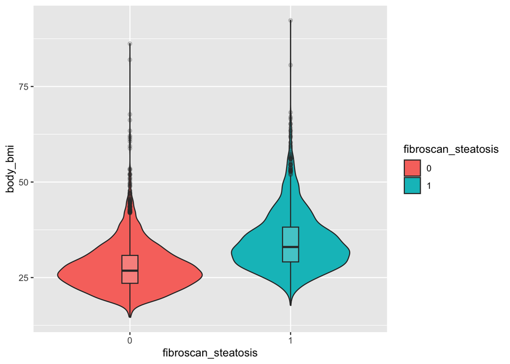

```r
#How does the strongest variable associate with the outcome? # BMI
#PLOT
plot1 <- ggplot(df, aes(x = fibroscan_steatosis, y = body_bmi)) +
  geom_violin(aes(fill = fibroscan_steatosis)) +
  geom_boxplot(width = 0.1, alpha = 0.2)



plot1
```

```r
summary(df$body_bmi)
```

```
   Min. 1st Qu.  Median    Mean 3rd Qu.    Max.
  14.60   25.00   28.90   30.15   33.90   92.30
```

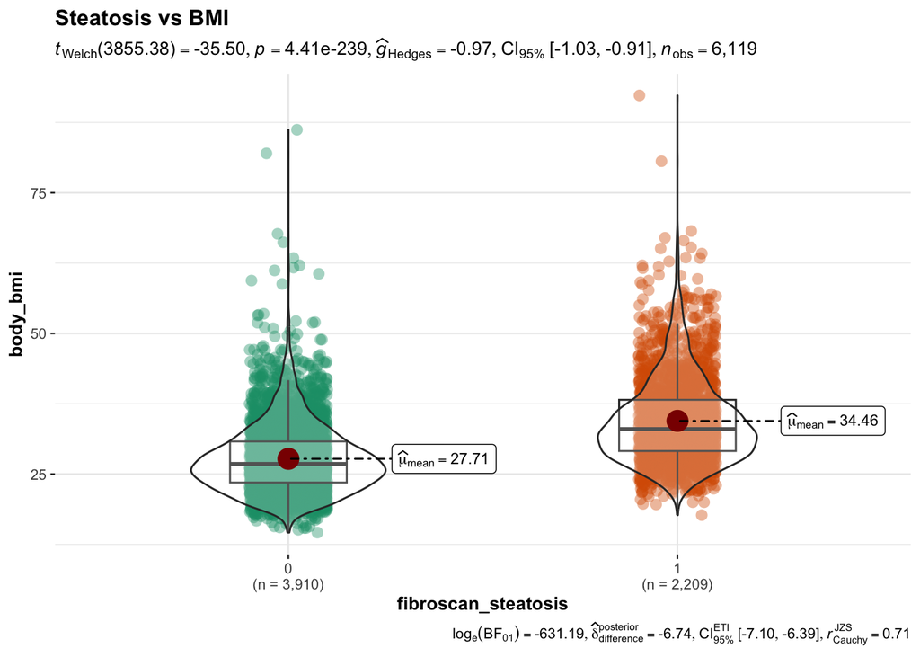

```r
ggbetweenstats(
  data  = df,
  x     = fibroscan_steatosis,
  y     = body_bmi,
  title = "Steatosis vs BMI ")
```

As a continuous variable

```r
model_steatosis_continuous <- glm(fibroscan_cap ~ alt + alb + alp + ast + urea + cr + ggt + ldh + na + tbil + chol + tg + etoh + ha1c +  insurance_covered + demo_gender + demo_age + demo_race + demo_education + body_bmi, data = df)

significant_results_steatosis_continuous <- tidy(model_steatosis_continuous)|> filter(p.value < 0.05) |> arrange(p.value) |> mutate(Odds_Ratio = exp(estimate))

significant_results_steatosis_continuous
```

```
# A tibble: 20 × 6
   term            estimate std.error statistic  p.value Odds_Ratio
   <chr>              <dbl>     <dbl>     <dbl>    <dbl>      <dbl>
 1 body_bmi          4.23     0.0917      46.2  0          6.90e+ 1
 2 demo_age          0.639    0.0431      14.8  8.55e-49   1.89e+ 0
 3 tg                0.111    0.00776     14.2  2.42e-45   1.12e+ 0
 4 ha1c              7.64     0.626       12.2  7.63e-34   2.08e+ 3
 5 demo_race4      -26.9      2.29       -11.8  1.34e-31   2.03e-12
 6 alt               0.571    0.0613       9.32 1.63e-20   1.77e+ 0
 7 demo_gender2    -13.1      1.41        -9.31 1.71e-20   2.07e- 6
 8 urea             -0.861    0.133       -6.47 1.07e-10   4.23e- 1
 9 demo_race3      -11.0      2.13        -5.15 2.74e- 7   1.70e- 5
10 alb               9.95     2.11         4.70 2.61e- 6   2.09e+ 4
11 ast              -0.355    0.0813      -4.37 1.26e- 5   7.01e- 1
12 demo_race2      -10.8      2.54        -4.26 2.10e- 5   2.03e- 5
13 demo_race7      -12.3      3.25        -3.78 1.58e- 4   4.64e- 6
14 demo_education3  10.2      2.86         3.57 3.54e- 4   2.80e+ 4
15 demo_education4   9.70     2.82         3.44 5.92e- 4   1.63e+ 4
16 tbil             -7.39     2.33        -3.17 1.53e- 3   6.19e- 4
17 na                0.691    0.240        2.88 3.98e- 3   2.00e+ 0
18 demo_education2   8.63     3.15         2.74 6.12e- 3   5.62e+ 3
19 demo_education5   6.64     2.94         2.26 2.40e- 2   7.65e+ 2
20 ldh              -0.0393   0.0197      -1.99 4.64e- 2   9.61e- 1
```

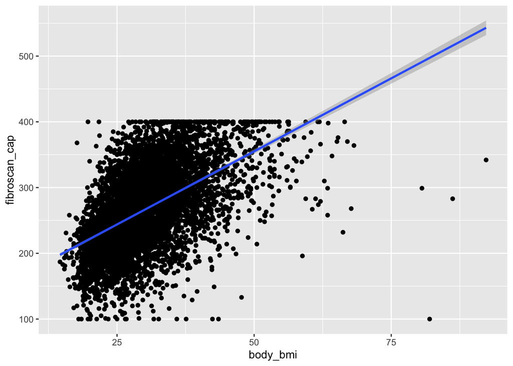

```r
#How does the strongest variable associate with the outcome? # BMI
#PLOT
plot2 <- ggplot(df, aes(x = body_bmi, y = fibroscan_cap)) + geom_point()+
  geom_smooth(method = "lm")


plot2
```

## 7 Identifying variables associated with Cirrhosis

```r
table(df$hbcore_positive)
```

```
   1    2    3
 449 5670    0
```

```r
model_cirrhosis_binary <- glm(fibroscan_cirrhosis ~ alt + alb + alp + ast + urea + cr + ggt + ldh + na + tbil + chol + tg + etoh + ha1c + insurance_covered + demo_gender + demo_age + demo_race + demo_education + body_bmi + hcab + hbcore_positive + hcrna, data = df, family = binomial)

summary(model_cirrhosis_binary)
```

```
Call:
glm(formula = fibroscan_cirrhosis ~ alt + alb + alp + ast + urea +
    cr + ggt + ldh + na + tbil + chol + tg + etoh + ha1c + insurance_covered +
    demo_gender + demo_age + demo_race + demo_education + body_bmi +
    hcab + hbcore_positive + hcrna, family = binomial, data = df)

Coefficients: (2 not defined because of singularities)
                     Estimate Std. Error z value Pr(>|z|)
(Intercept)        -5.661e+00  6.198e+00  -0.913  0.36104
alt                -1.314e-02  6.022e-03  -2.183  0.02907 *
alb                -1.476e+00  3.429e-01  -4.306 1.66e-05 ***
alp                 7.308e-03  3.156e-03   2.315  0.02059 *
ast                 2.390e-02  7.572e-03   3.156  0.00160 **
urea                1.063e-02  1.687e-02   0.630  0.52874
cr                  4.006e-04  1.844e-01   0.002  0.99827
ggt                 1.956e-03  1.528e-03   1.280  0.20053
ldh                 5.765e-03  2.190e-03   2.633  0.00847 **
na                  5.326e-03  4.113e-02   0.129  0.89697
tbil                1.381e+00  2.957e-01   4.670 3.01e-06 ***
chol               -2.711e-03  2.968e-03  -0.913  0.36116
tg                  2.411e-03  9.535e-04   2.529  0.01144 *
etoh               -1.246e-02  2.530e-01  -0.049  0.96074
ha1c                6.279e-02  8.131e-02   0.772  0.43996
insurance_covered2 -6.664e-01  3.926e-01  -1.697  0.08960 .
insurance_covered7 -1.636e+01  2.400e+03  -0.007  0.99456
insurance_covered9 -1.056e+01  8.873e+02  -0.012  0.99050
demo_gender2       -1.348e+00  2.740e-01  -4.920 8.67e-07 ***
demo_age            1.147e-02  8.543e-03   1.342  0.17945
demo_race2          6.609e-01  4.979e-01   1.327  0.18441
demo_race3          5.031e-01  4.400e-01   1.143  0.25287
demo_race4          1.564e-01  4.684e-01   0.334  0.73848
demo_race6          1.046e+00  5.892e-01   1.775  0.07597 .
demo_race7         -2.647e-02  6.626e-01  -0.040  0.96813
demo_education2    -1.735e-01  5.436e-01  -0.319  0.74960
demo_education3    -1.956e-01  5.020e-01  -0.390  0.69684
demo_education4     9.847e-03  4.848e-01   0.020  0.98380
demo_education5    -3.891e-01  5.383e-01  -0.723  0.46973
demo_education7     4.764e+00  3.393e+03   0.001  0.99888
demo_education9    -1.231e+01  1.171e+03  -0.011  0.99161
body_bmi            1.207e-01  1.197e-02  10.082  < 2e-16 ***
hcab2              -3.258e-01  1.225e+00  -0.266  0.79030
hcab3              -1.127e+00  6.280e-01  -1.794  0.07277 .
hcab4               9.067e-01  7.580e-01   1.196  0.23165
hbcore_positive2    2.805e-01  4.274e-01   0.656  0.51164
hcrna2                     NA         NA      NA       NA
hcrna3                     NA         NA      NA       NA
---
Signif. codes:  0 '***' 0.001 '**' 0.01 '*' 0.05 '.' 0.1 ' ' 1

(Dispersion parameter for binomial family taken to be 1)

    Null deviance: 1094.11  on 6118  degrees of freedom
Residual deviance:  758.91  on 6083  degrees of freedom
AIC: 830.91

Number of Fisher Scoring iterations: 15
```

```r
significant_results_cirrhosis_binary <- tidy(model_cirrhosis_binary)|> filter(p.value < 0.05) |> arrange(p.value) |> mutate(Odds_Ratio = exp(estimate))

significant_results_cirrhosis_binary
```

```
# A tibble: 9 × 6
  term         estimate std.error statistic  p.value Odds_Ratio
  <chr>           <dbl>     <dbl>     <dbl>    <dbl>      <dbl>
1 body_bmi      0.121    0.0120       10.1  6.63e-24      1.13
2 demo_gender2 -1.35     0.274        -4.92 8.67e- 7      0.260
3 tbil          1.38     0.296         4.67 3.01e- 6      3.98
4 alb          -1.48     0.343        -4.31 1.66e- 5      0.228
5 ast           0.0239   0.00757       3.16 1.60e- 3      1.02
6 ldh           0.00577  0.00219       2.63 8.47e- 3      1.01
7 tg            0.00241  0.000953      2.53 1.14e- 2      1.00
8 alp           0.00731  0.00316       2.32 2.06e- 2      1.01
9 alt          -0.0131   0.00602      -2.18 2.91e- 2      0.987
```

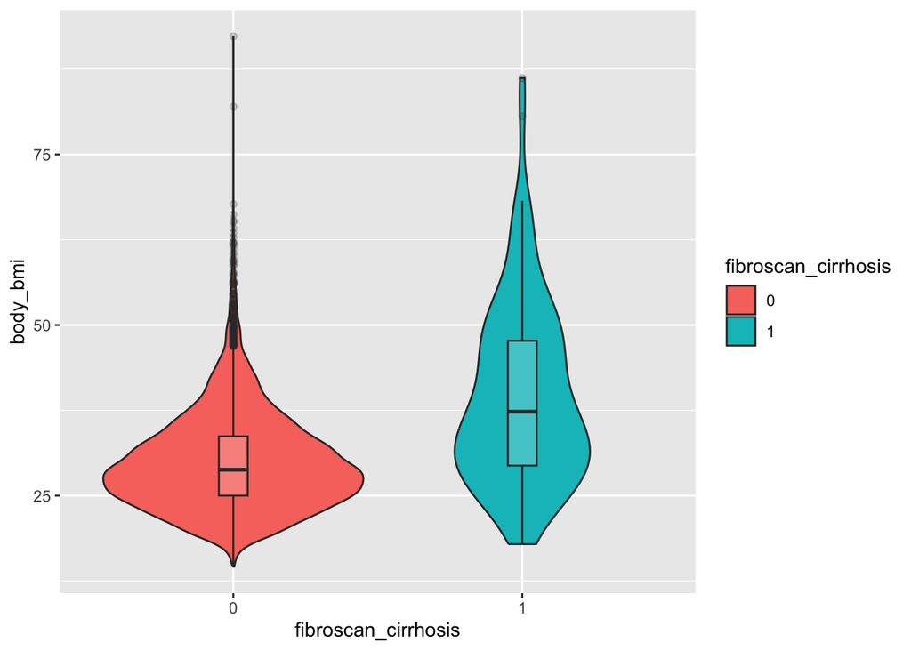

```r
#How does the strongest variable associate with the outcome? \# BMI

#PLOT

plot10 <- ggplot(data=df, aes(x = fibroscan_cirrhosis, y = body_bmi)) +

geom_violin(aes(fill = fibroscan_cirrhosis)) +

geom_boxplot(width = 0.1, alpha = 0.2)


plot10
```

```r
#
```

As a continuous variable

```r
model_cirrhosis_continuous <- glm(fibroscan_meanstiffness_kpa ~ alt + alb + alp + ast + urea + cr + ggt + ldh + na + tbil + chol + tg + etoh + ha1c + insurance_covered + demo_gender + demo_age + demo_race + demo_education + body_bmi + hcab + hbcore_positive + hcrna, data = df)

significant_results_cirrhosis_continuous <- tidy(model_cirrhosis_continuous)|> filter(p.value < 0.05) |> arrange(p.value) |> mutate(Odds_Ratio = exp(estimate))

significant_results_cirrhosis_continuous
```

```
# A tibble: 13 × 6
   term         estimate std.error statistic  p.value Odds_Ratio
   <chr>           <dbl>     <dbl>     <dbl>    <dbl>      <dbl>
 1 body_bmi      0.196     0.00965     20.3  4.46e-89     1.22
 2 ast           0.0672    0.00860      7.82 6.18e-15     1.07
 3 tbil          1.45      0.245        5.92 3.47e- 9     4.26
 4 ggt           0.00899   0.00169      5.30 1.17e- 7     1.01
 5 demo_gender2 -0.770     0.148       -5.21 1.97e- 7     0.463
 6 alt          -0.0326    0.00645     -5.06 4.38e- 7     0.968
 7 hcab3        -2.32      0.566       -4.10 4.15e- 5     0.0981
 8 ha1c          0.247     0.0658       3.76 1.74e- 4     1.28
 9 chol         -0.00525   0.00169     -3.11 1.90e- 3     0.995
10 hcab2        -2.70      1.10        -2.45 1.44e- 2     0.0673
11 alb          -0.515     0.223       -2.31 2.09e- 2     0.597
12 alp           0.00625   0.00276      2.26 2.38e- 2     1.01
13 ldh           0.00437   0.00208      2.11 3.52e- 2     1.00
```

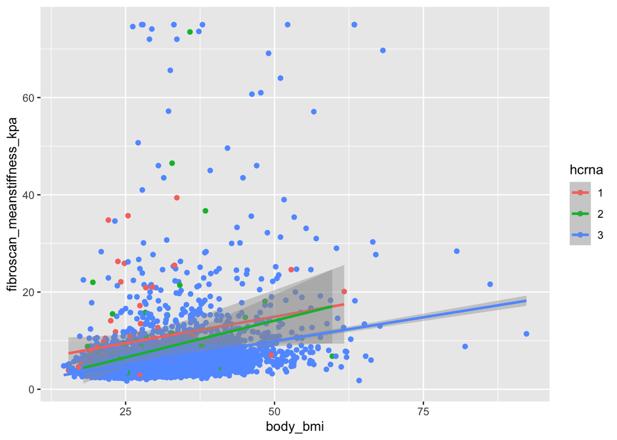

```r
#How does the strongest variable associate with the outcome? # BMI
#PLOT to see the number of hcrna
plot11 <- ggplot(df, aes(x = body_bmi, y = fibroscan_meanstiffness_kpa, color=hcrna)) + geom_point()+
  geom_smooth(method = "lm")

plot11
```

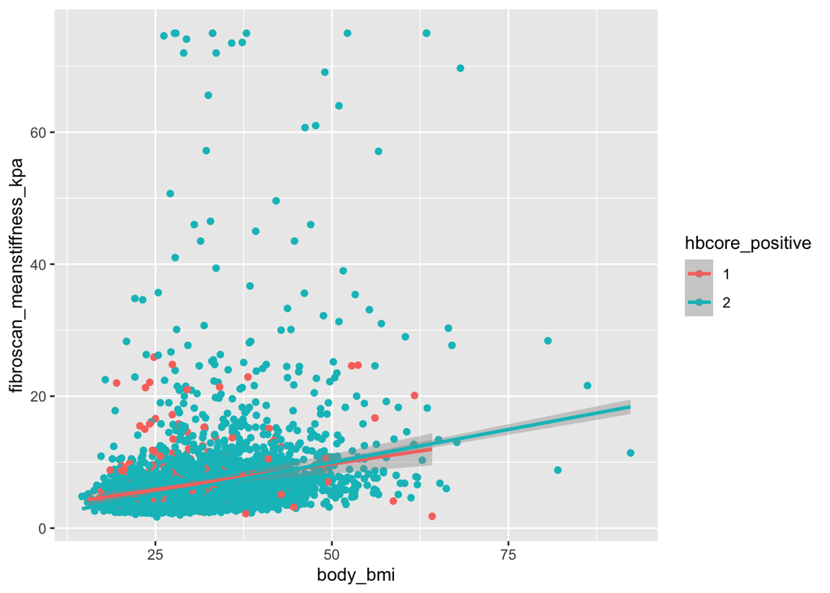

```r
#PLOT to see the numebr of hb
plot12 <- ggplot(df, aes(x = body_bmi, y = fibroscan_meanstiffness_kpa, color=hbcore_positive)) + geom_point()+
  geom_smooth(method = "lm")

plot12
```

## 8 Supervised machine learning using Random Forest Model to assess most important factors/GINI in Steatosis

```r
#We will convert 1-> Cases and 0-> Controls
#Steatosis
df<- df |>
  mutate(fibroscan_steatosis = ifelse(fibroscan_steatosis == 1, "Cases", "Controls"))

table(df$fibroscan_steatosis)
```

```
   Cases Controls
    2209     3910
```

```r
df$fibroscan_steatosis <-  as.factor(df$fibroscan_steatosis)
```

create a new data frame without any other fibroscan data except for fibroscan_steatosis and fibroscan_cirrhosis as they will automatically serve as a predictor

```r
df <- subset(df, select = -c(fibroscan_meanstiffness_kpa, fibroscan_cap, fibroscan_stiffnessiqr))
```

```r
#Random forest model
rf_cls_spec <-
  rand_forest(trees = 1000, min_n = 5) |>
  set_engine("randomForest", importance = TRUE) |>
  set_mode("classification")

rf_cls_spec
```

```
Random Forest Model Specification (classification)

Main Arguments:
  trees = 1000
  min_n = 5

Engine-Specific Arguments:
  importance = TRUE

Computational engine: randomForest
```

```r
rf_cls_fit_steatosis <- rf_cls_spec |>
  fit(fibroscan_steatosis ~ alt + alb + alp + ast + urea + cr + ggt + ldh + na + tbil + chol + tg + etoh + ha1c +  insurance_covered + demo_gender + demo_age + demo_race + demo_education + body_bmi, data = df)


rf_cls_fit_steatosis
```

```
parsnip model object


Call:
 randomForest(x = maybe_data_frame(x), y = y, ntree = ~1000, nodesize = min_rows(~5,      x), importance = ~TRUE)
               Type of random forest: classification
                     Number of trees: 1000
No. of variables tried at each split: 4

        OOB estimate of  error rate: 23.32%
Confusion matrix:
         Cases Controls class.error
Cases     1333      876   0.3965595
Controls   551     3359   0.1409207
```

```r
#for importance scores
rf_cls_fit_steatosis |>
  extract_fit_engine() |>
  importance()
```

```
                         Cases   Controls MeanDecreaseAccuracy MeanDecreaseGini
alt                43.26788902 23.4998089           49.9151365       171.245093
alb                12.88112299  4.4059595           12.6184934        81.887232
alp                -1.96163262 13.0583846            9.1915704       110.848653
ast                10.26692671 16.9901098           23.4304876        91.315289
urea                4.81899624  8.5368189           10.5957389        85.380995
cr                 -2.40281188 22.7328761           17.8412094       117.004577
ggt                53.66285092  8.8283333           49.1372411       176.236229
ldh                -0.46207092 13.3454432           10.3455395       110.114333
na                 -1.29111978  0.4301562           -0.4973667        66.786212
tbil               -1.65316648  2.8991526            1.0657114        56.818319
chol               -2.19361489 11.8510506            7.8982417       116.439768
tg                 53.15770343 26.3236782           54.7432683       244.858150
etoh                0.03900159  0.6842321            0.5970400        11.634733
ha1c               45.51590754 39.7189853           58.5713498       202.523808
insurance_covered  -2.07685457  0.7010081           -0.8697948         9.644781
demo_gender         7.59963082 16.9212113           19.6520097        21.664570
demo_age           14.44294110 15.0633838           22.7685956       119.773147
demo_race          18.73082097 15.2747596           24.2518264        96.712488
demo_education     -0.83990366  4.0513209            2.6495310        67.153939
body_bmi          124.12859323 95.4117445          139.8659635       503.708059
```

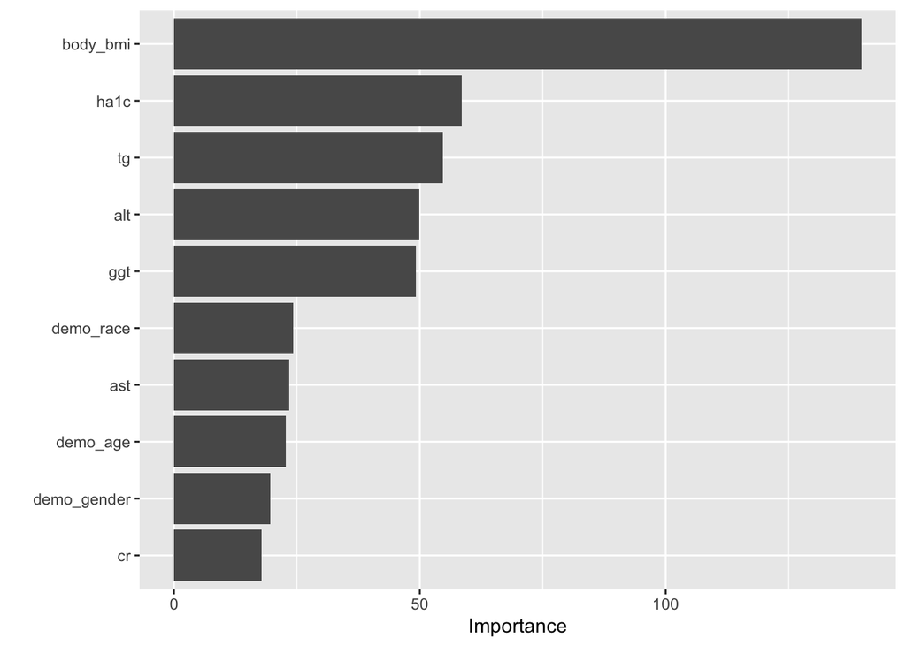

```r
#to plot MeanDecreaseGini
plot3 <- rf_cls_fit_steatosis |>
  extract_fit_engine() |>
  vip()

plot3
```

```r
#save
rf.predicted.steatosis <- bind_cols(
  truth = df$fibroscan_steatosis,
  predict(rf_cls_fit_steatosis, df),
  predict(rf_cls_fit_steatosis, df, type = "prob")
)


rf.predicted.steatosis
```

```
# A tibble: 6,119 × 4
   truth    .pred_class .pred_Cases .pred_Controls
   <fct>    <fct>             <dbl>          <dbl>
 1 Controls Controls          0.126          0.874
 2 Cases    Cases             0.592          0.408
 3 Controls Controls          0.087          0.913
 4 Controls Controls          0.196          0.804
 5 Cases    Cases             0.682          0.318
 6 Cases    Cases             0.774          0.226
 7 Controls Controls          0.26           0.74
 8 Cases    Cases             0.74           0.26
 9 Controls Controls          0.04           0.96
10 Cases    Cases             0.9            0.1
# ℹ 6,109 more rows
```

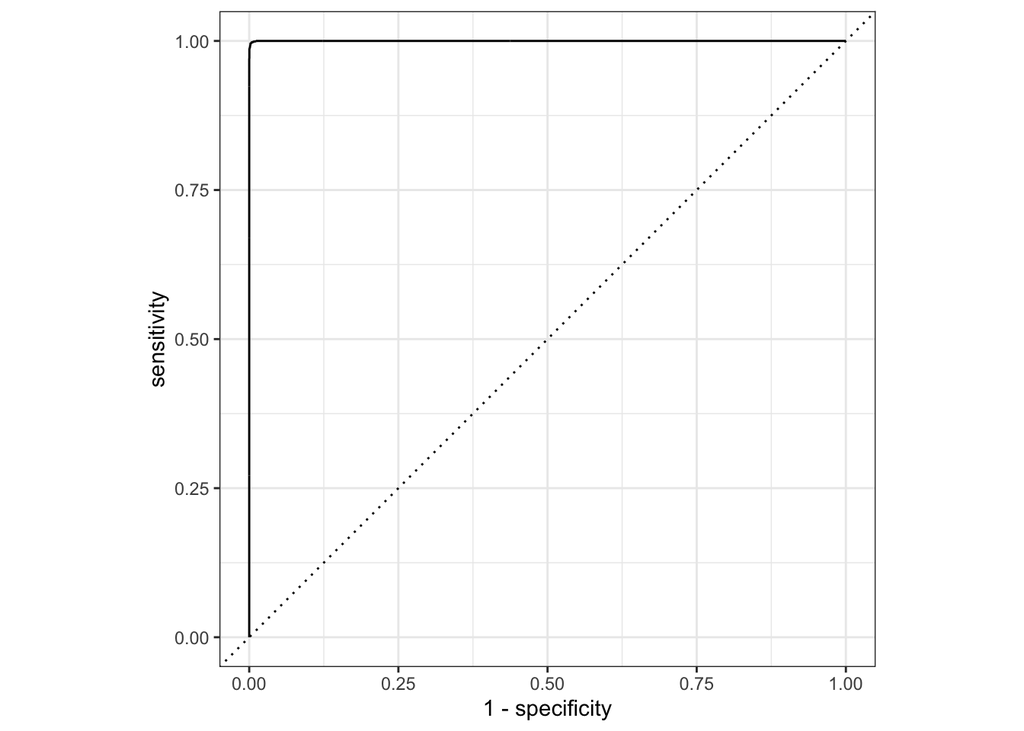

```r
#RF plots

plot4 <- autoplot(roc_curve(rf.predicted.steatosis,
                   truth, .pred_Cases ))

plot4
```

```r
plot5 <- roc_auc(rf.predicted.steatosis,
                   truth,  .pred_Cases )


plot5
```

```
# A tibble: 1 × 3
  .metric .estimator .estimate
  <chr>   <chr>          <dbl>
1 roc_auc binary          1.00
```

```r
set.seed(1234)

data.split <- initial_split(df,
                            strata = fibroscan_steatosis,
                            prop = 0.80)

data.split
```

```
<Training/Testing/Total>
<4895/1224/6119>
```

```r
data.train <- training(data.split)
data.test <- testing(data.split)
```

Training based on RF model

```r
rf_cls_fit_train<- rf_cls_spec |>
  fit(fibroscan_steatosis ~ ., data = data.train)


rf_cls_fit_train
```

```
parsnip model object


Call:
 randomForest(x = maybe_data_frame(x), y = y, ntree = ~1000, nodesize = min_rows(~5,      x), importance = ~TRUE)
               Type of random forest: classification
                     Number of trees: 1000
No. of variables tried at each split: 5

        OOB estimate of  error rate: 22.64%
Confusion matrix:
         Cases Controls class.error
Cases     1098      669   0.3786078
Controls   439     2689   0.1403453
```

Testing based on RF model

```r
data.rf.pred.values.test <-  bind_cols(
  truth = data.test$fibroscan_steatosis,
  predict(rf_cls_fit_train, data.test),
  predict(rf_cls_fit_train, data.test, type = "prob")
)


data.rf.pred.values.test
```

```
# A tibble: 1,224 × 4
   truth    .pred_class .pred_Cases .pred_Controls
   <fct>    <fct>             <dbl>          <dbl>
 1 Cases    Controls          0.208          0.792
 2 Cases    Cases             0.575          0.425
 3 Cases    Controls          0.473          0.527
 4 Controls Controls          0.389          0.611
 5 Controls Controls          0.085          0.915
 6 Controls Cases             0.562          0.438
 7 Cases    Controls          0.358          0.642
 8 Cases    Cases             0.718          0.282
 9 Controls Cases             0.509          0.491
10 Cases    Cases             0.727          0.273
# ℹ 1,214 more rows
```

ROC and AUC

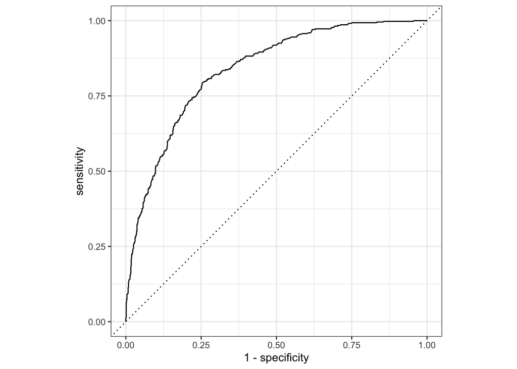

```r
plot6 <- autoplot(roc_curve(data.rf.pred.values.test,
                   truth, .pred_Cases))

plot6
```

```r
plot7 <- roc_auc(data.rf.pred.values.test,
                   truth, .pred_Cases)

plot7
```

```
# A tibble: 1 × 3
  .metric .estimator .estimate
  <chr>   <chr>          <dbl>
1 roc_auc binary         0.837
```

## 9 Unsupervised machine learning using Kmeans clustering in Steatosis

```r
set.seed(1234)

df.kmeans <- kmeans(df[ , 1:24], 2)
df.kmeans
```

```
K-means clustering with 2 clusters of sizes 995, 5124

Cluster means:
       alt      alb      alp      ast     urea        cr      ggt      ldh
1 29.18392 4.084121 82.52462 24.49648 15.97990 0.9291658 50.20201 157.3598
2 21.16608 4.064637 76.09719 21.39617 14.70258 0.9015925 28.89325 158.0911
        na      tbil     chol       tg     etoh     ha1c hc_self_cpiqr
1 140.1518 0.4215075 209.5337 286.6874 1.827136 6.250854      33.63618
2 140.6899 0.4695160 181.1401 105.3134 1.859875 5.754313      37.62627
  insurance_covered demo_gender demo_age demo_race demo_education body_bmi
1           1.20000    1.361809 52.31960  3.204020       3.437186 31.91015
2           1.16491    1.516784 50.13661  3.418033       3.659251 29.80289
  hb_self_reported hc_self_reported hc_self_reported.1
1         2.006030         2.009045           2.009045
2         2.020101         2.011905           2.011905
```

[output cut: 777 more lines]

```r
table(df$fibroscan_steatosis, df.kmeans$cluster)
```

```
              1    2
  Cases     598 1611
  Controls  397 3513
```

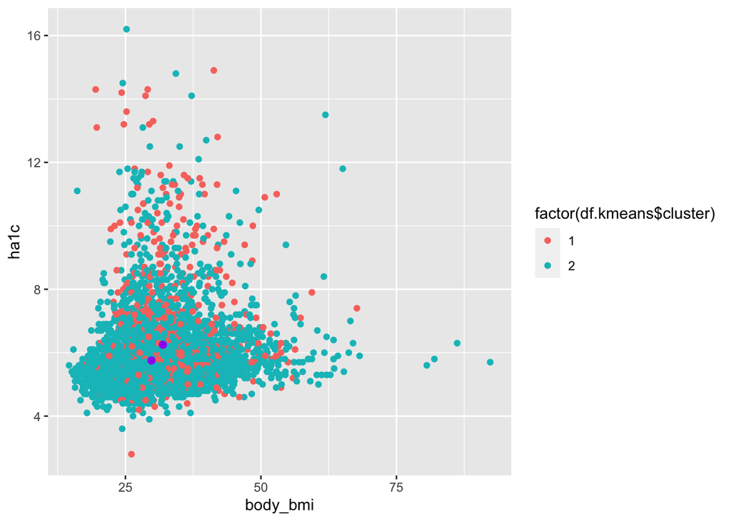

```r
centers <- as.data.frame(df.kmeans$centers)


plot8 <- ggplot(data = df) +
    geom_point(aes(body_bmi, ha1c,
                        color = factor(df.kmeans$cluster))) +
    geom_point(data = centers, aes(body_bmi, ha1c),
               color = "purple", size = 2)

plot8
```

## 10 Supervised machine learning using Random Forest Model to assess most important factors/GINI in Cirrhosis

```r
#We will convert 1-> Cases and 0-> Controls
#Steatosis
df<- df |>
  mutate(fibroscan_cirrhosis = ifelse(fibroscan_cirrhosis == 1, "Cases", "Controls"))

table(df$fibroscan_cirrhosis)
```

```
   Cases Controls
     109     6010
```

```r
df$fibroscan_cirrhosis <-  as.factor(df$fibroscan_cirrhosis)
```

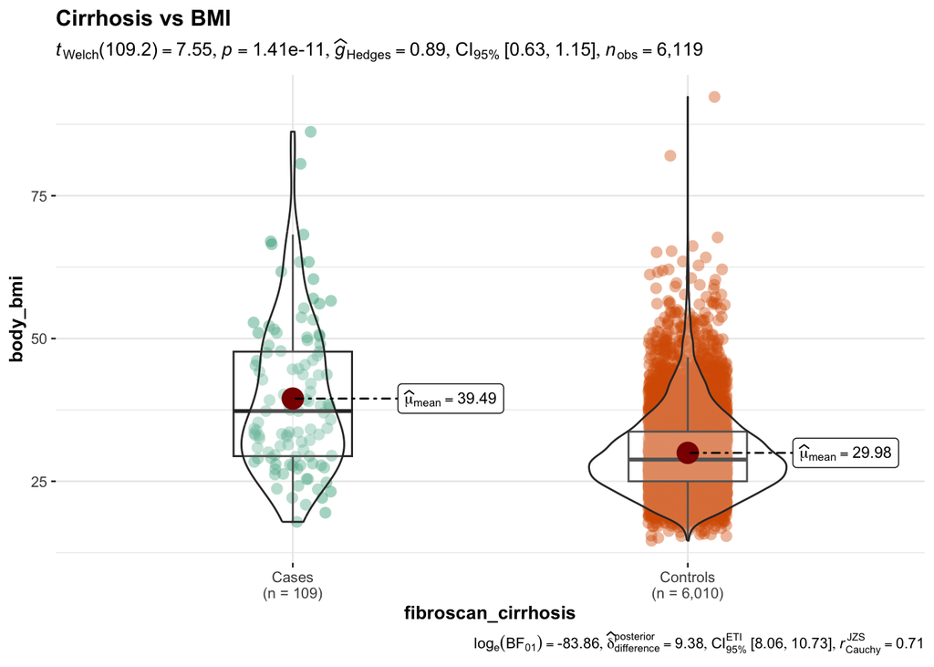

```r
ggbetweenstats(
  data  = df,
  x     = fibroscan_cirrhosis,
  y     = body_bmi,
  title = "Cirrhosis vs BMI ")
```

```r
#Random forest model
rf_cls_spec <-
  rand_forest(trees = 1000, min_n = 5) |>
  set_engine("randomForest", importance = TRUE) |>
  set_mode("classification")

rf_cls_spec
```

```
Random Forest Model Specification (classification)

Main Arguments:
  trees = 1000
  min_n = 5

Engine-Specific Arguments:
  importance = TRUE

Computational engine: randomForest
```

```r
rf_cls_fit_cirrhosis <- rf_cls_spec |>
  fit(fibroscan_cirrhosis ~ alt + alb + alp + ast + urea + cr + ggt + ldh + na + tbil + chol + tg + etoh + ha1c + insurance_covered + demo_gender + demo_age + demo_race + demo_education + body_bmi + hcab + hbcore_positive + hcrna, data = df)


rf_cls_fit_cirrhosis
```

```
parsnip model object


Call:
 randomForest(x = maybe_data_frame(x), y = y, ntree = ~1000, nodesize = min_rows(~5,      x), importance = ~TRUE)
               Type of random forest: classification
                     Number of trees: 1000
No. of variables tried at each split: 4

        OOB estimate of  error rate: 1.83%
Confusion matrix:
         Cases Controls  class.error
Cases        1      108 0.9908256881
Controls     4     6006 0.0006655574
```

```r
#for importance scores
rf_cls_fit_cirrhosis |>
  extract_fit_engine() |>
  importance()
```

```
                        Cases    Controls MeanDecreaseAccuracy MeanDecreaseGini
alt               -0.71229187 14.59273872           15.1872964        7.9252118
alb               12.46482099 14.79223333           17.4390842        8.4356280
alp               12.42697700  3.38075249            7.0562020       11.9331362
ast               12.50653795  9.80399117           11.5730609        9.2186021
urea              -1.18788449  9.85177544            9.5706653        7.2163847
cr                -0.31735998 13.74012774           13.8680114        8.0419054
ggt               14.81646114  4.88792309            8.6873163       10.8721959
ldh                5.11625436  5.71388665            6.9390205       11.5600712
na                 0.91759659  0.01492991            0.2285551        5.4307804
tbil              10.63420464  9.13289595           11.9000997        7.3117497
chol               3.01143224  2.86092983            3.4832066        9.3489920
tg                -0.02223564  5.19290592            5.2128027        8.7317406
etoh               0.64118901  3.04003500            3.0569302        1.3726879
ha1c               6.82846786  4.69231049            6.0176098        7.7142665
insurance_covered -1.52438408  4.11098061            3.6749184        0.5940544
demo_gender        0.06454764 15.79365642           15.7310349        1.8535442
demo_age          -1.86747759 13.09220004           12.9026842        6.0835902
demo_race         -2.81088625  8.94113961            8.1466809        5.0023135
demo_education     0.34335619  3.01451244            3.0418969        4.6297653
body_bmi          32.73825081 18.91319483           26.0798979       23.1840585
hcab               7.26908226  4.69870874            6.7055249        2.1654800
hbcore_positive    0.94938186 -0.63337453           -0.3311197        0.6728959
hcrna              6.38721664  4.58208233            6.3579045        1.7945368
```

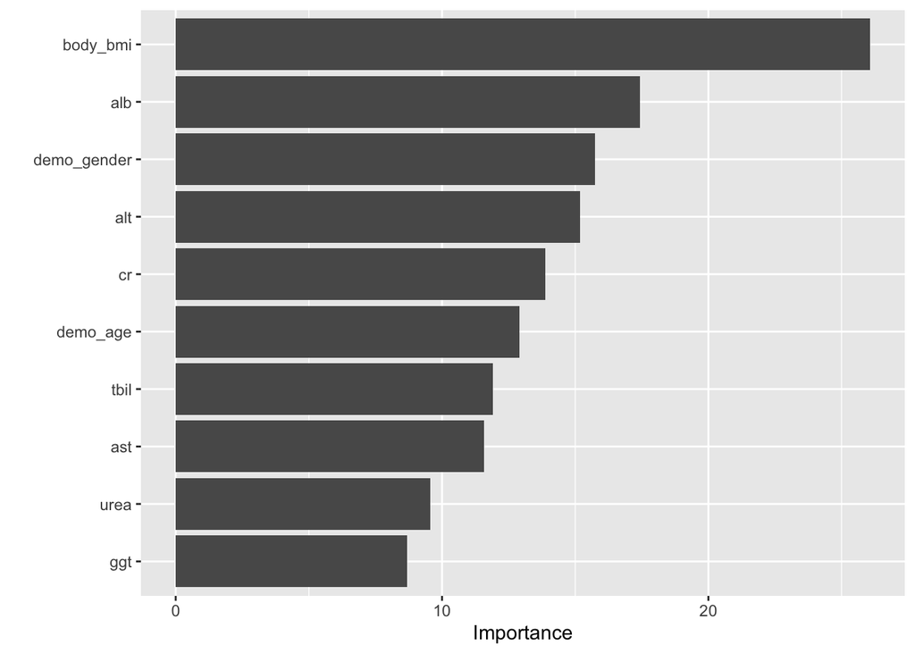

```r
#to plot MeanDecreaseGini
rf_cls_fit_cirrhosis |>
  extract_fit_engine() |>
  vip()
```

```r
#save
rf.predicted.cirrhosis <- bind_cols(
  truth = df$fibroscan_cirrhosis,
  predict(rf_cls_fit_cirrhosis, df),
  predict(rf_cls_fit_cirrhosis, df, type = "prob")
)


rf.predicted.cirrhosis
```

```
# A tibble: 6,119 × 4
   truth    .pred_class .pred_Cases .pred_Controls
   <fct>    <fct>             <dbl>          <dbl>
 1 Controls Controls          0.001          0.999
 2 Controls Controls          0.001          0.999
 3 Controls Controls          0.001          0.999
 4 Controls Controls          0.005          0.995
 5 Controls Controls          0.002          0.998
 6 Controls Controls          0              1
 7 Controls Controls          0.002          0.998
 8 Controls Controls          0.015          0.985
 9 Controls Controls          0.002          0.998
10 Cases    Cases             0.507          0.493
# ℹ 6,109 more rows
```

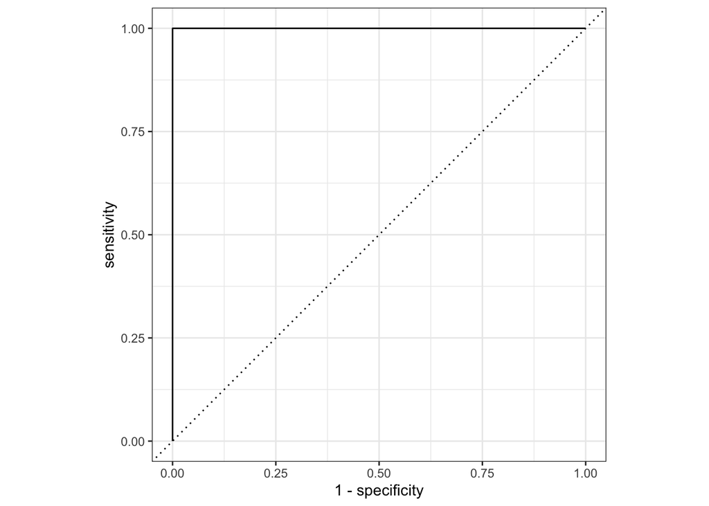

```r
#RF plots

plot13 <- autoplot(roc_curve(rf.predicted.cirrhosis,
                   truth, .pred_Cases ))

plot13
```

```r
plot14 <- roc_auc(rf.predicted.cirrhosis,
                   truth,  .pred_Cases )


plot14
```

```
# A tibble: 1 × 3
  .metric .estimator .estimate
  <chr>   <chr>          <dbl>
1 roc_auc binary             1
```

```r
set.seed(1234)

data.split <- initial_split(df,
                            strata = fibroscan_cirrhosis,
                            prop = 0.80)

data.split
```

```
<Training/Testing/Total>
<4895/1224/6119>
```

```r
data.train <- training(data.split)
data.test <- testing(data.split)
```

Training based on RF model

```r
rf_cls_fit_train<- rf_cls_spec |>
  fit(fibroscan_cirrhosis ~ ., data = data.train)


rf_cls_fit_train
```

```
parsnip model object


Call:
 randomForest(x = maybe_data_frame(x), y = y, ntree = ~1000, nodesize = min_rows(~5,      x), importance = ~TRUE)
               Type of random forest: classification
                     Number of trees: 1000
No. of variables tried at each split: 5

        OOB estimate of  error rate: 1.74%
Confusion matrix:
         Cases Controls  class.error
Cases        1       82 0.9879518072
Controls     3     4809 0.0006234414
```

Testing based on RF model

```r
data.rf.pred.values.test <-  bind_cols(
  truth = data.test$fibroscan_cirrhosis,
  predict(rf_cls_fit_train, data.test),
  predict(rf_cls_fit_train, data.test, type = "prob")
)


data.rf.pred.values.test
```

```
# A tibble: 1,224 × 4
   truth    .pred_class .pred_Cases .pred_Controls
   <fct>    <fct>             <dbl>          <dbl>
 1 Controls Controls          0.004          0.996
 2 Controls Controls          0.002          0.998
 3 Controls Controls          0.014          0.986
 4 Controls Controls          0.001          0.999
 5 Controls Controls          0.004          0.996
 6 Controls Controls          0              1
 7 Controls Controls          0.002          0.998
 8 Controls Controls          0              1
 9 Controls Controls          0.016          0.984
10 Controls Controls          0.007          0.993
# ℹ 1,214 more rows
```

ROC and AUC Curves

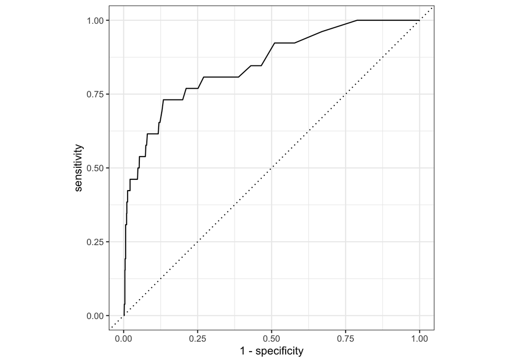

```r
autoplot(roc_curve(data.rf.pred.values.test,
                   truth, .pred_Cases))
```

```r
roc_auc(data.rf.pred.values.test,
                   truth, .pred_Cases)
```

```
# A tibble: 1 × 3
  .metric .estimator .estimate
  <chr>   <chr>          <dbl>
1 roc_auc binary         0.849
```

## 11 Unsupervised machine learning using Kmeans clustering in cirrhosis

```r
set.seed(1234)

df.kmeans <- kmeans(df[ , 1:24], 2)
df.kmeans
```

```
K-means clustering with 2 clusters of sizes 995, 5124

Cluster means:
       alt      alb      alp      ast     urea        cr      ggt      ldh
1 29.18392 4.084121 82.52462 24.49648 15.97990 0.9291658 50.20201 157.3598
2 21.16608 4.064637 76.09719 21.39617 14.70258 0.9015925 28.89325 158.0911
        na      tbil     chol       tg     etoh     ha1c hc_self_cpiqr
1 140.1518 0.4215075 209.5337 286.6874 1.827136 6.250854      33.63618
2 140.6899 0.4695160 181.1401 105.3134 1.859875 5.754313      37.62627
  insurance_covered demo_gender demo_age demo_race demo_education body_bmi
1           1.20000    1.361809 52.31960  3.204020       3.437186 31.91015
2           1.16491    1.516784 50.13661  3.418033       3.659251 29.80289
  hb_self_reported hc_self_reported hc_self_reported.1
1         2.006030         2.009045           2.009045
2         2.020101         2.011905           2.011905
```

[output cut: 777 more lines]

```r
table(df$fibroscan_cirrhosis, df.kmeans$cluster)
```

```
              1    2
  Cases      29   80
  Controls  966 5044
```

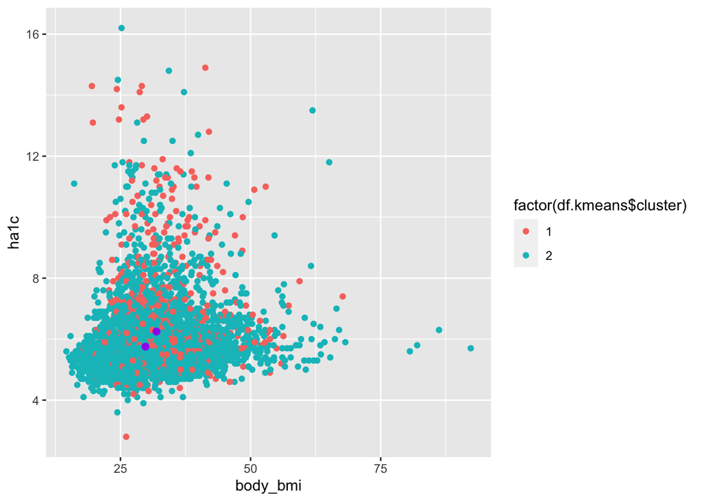

```r
centers <- as.data.frame(df.kmeans$centers)


ggplot(data = df) +
    geom_point(aes(body_bmi, ha1c,
                        color = factor(df.kmeans$cluster))) +
    geom_point(data = centers, aes(body_bmi, ha1c),
               color = "purple", size = 2)
```

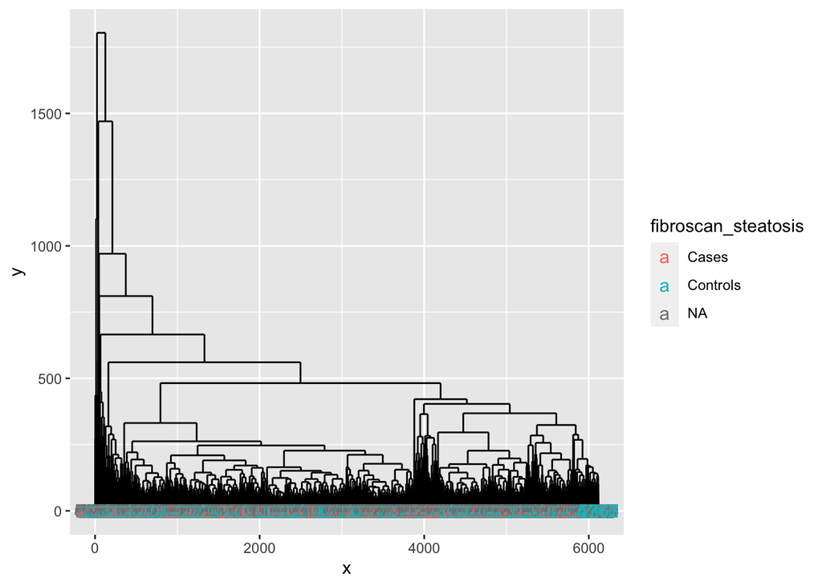

```r
df.hclust <- hclust(dist(df), method = "complete")
df.dend <- dendro_data(as.dendrogram(df.hclust))

labels <- label(df.dend)

labels$fibroscan_steatosis <- df$fibroscan_steatosis[as.numeric(labels$label)]

plot15 <- ggplot(segment(df.dend)) +
    geom_segment(aes(x = x, y = y, xend = xend, yend = yend)) +
    geom_text(data = labels, aes(label = label, x = x, y = 0,
                                 color = fibroscan_steatosis), size = 4)


plot15
```

```r
df.cut <- cutree(df.hclust, 11) #Cut where there are 11 clusters
df.comparison <- table(df$fibroscan_steatosis, df.cut)

df.comparison
```

```
          df.cut
              1    2    3    4    5    6    7    8    9   10   11
  Cases    1068  924   29  154    0   28    1    4    0    0    1
  Controls 2460 1318   31   83    1    5    1    5    4    2    0
```

all plots (using cowplot)

[figure not shown]

```r
combined_plot <- plot_grid(plot1, plot2, plot3, plot4, plot5, plot6, plot7, plot8, plot10, plot11, plot12, plot13, plot14,plot15)
combined_plot
```

## 12 Conclusion

In summary, we realize that BMI is a strong predictor for the occurence of hepatic steatosis and cirrhosis. Other variables which are associated with each include alt, alb, gender (cirrhosis) and a1c, tg and alt (steatosis).